# Lake Water Quality Analysis

Matthew Ross, Devin Hunt

2/24/2022

# LAGOS Analysis

## Loading in data

### First download and then specifically grab the locus (or site lat longs)

```r
#Lagos download script
#lagosne_get(dest_folder = LAGOSNE:::lagos_path(),overwrite=T)

#Load in lagos
lagos <- lagosne_load()


#Grab the lake centroid info
lake_centers <- lagos$locus

# Make an sf object
spatial_lakes <- st_as_sf(lake_centers,coords=c('nhd_long','nhd_lat'),
                          crs=4326)

#Grab the water quality data
nutr <- lagos$epi_nutr

#Look at column names
#names(nutr)
```

### Subset columns nutr to only keep key info that we want

```r
clarity_only <- nutr %>%
  select(lagoslakeid,sampledate,chla,doc,secchi) %>%
  mutate(sampledate = as.character(sampledate) %>% ymd(.))
```

### Keep sites with at least 200 observations

```r
#Look at the number of rows of dataset
#nrow(clarity_only)

chla_secchi <- clarity_only %>%
  filter(!is.na(chla),
         !is.na(secchi))

# How many observations did we lose?
# nrow(clarity_only) - nrow(chla_secchi)


# Keep only the lakes with at least 200 observations of secchi and chla
chla_secchi_200 <- chla_secchi %>%
  group_by(lagoslakeid) %>%
  mutate(count = n()) %>%
  filter(count > 200)
```

### Join water quality data to spatial data

```r
spatial_200 <- inner_join(spatial_lakes,chla_secchi_200 %>%
                            distinct(lagoslakeid,.keep_all=T),
                          by='lagoslakeid')
```

### Mean Chl_a map

```r
### Take the mean chl_a and secchi by lake

mean_values_200 <- chla_secchi_200 %>%
  # Take summary by lake id
  group_by(lagoslakeid) %>%
  # take mean chl_a per lake id
  summarize(mean_chl = mean(chla,na.rm=T),
            mean_secchi=mean(secchi,na.rm=T)) %>%
  #Get rid of NAs
  filter(!is.na(mean_chl),
         !is.na(mean_secchi)) %>%
  # Take the log base 10 of the mean_chl
  mutate(log10_mean_chl = log10(mean_chl))

#Join datasets
mean_spatial <- inner_join(spatial_lakes,mean_values_200,
                          by='lagoslakeid')

#Make a map
mapview(mean_spatial,zcol='log10_mean_chl')
```

[interactive chart not shown]

# Class work

## 1) What is the correlation between Secchi Disk Depth and Chlorophyll a for sites with at least 200 observations?

- Here, I just want a plot of chla vs secchi for all sites

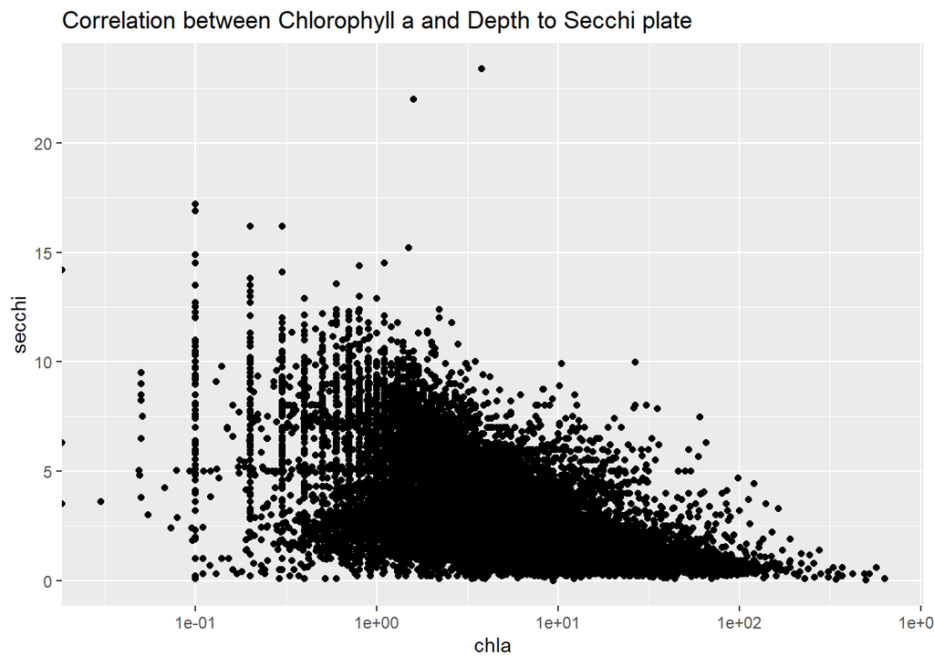

```r
#Your code here
ggplot(chla_secchi_200, aes(x = chla, y = secchi)) +
  geom_point() + scale_x_log10() + labs(title = "Correlation between Chlorophyll a and Depth to Secchi plate")
```

## Why might this be the case?

### 2a) First you will need to make a lagos spatial dataset that has the total number of counts per site.

```r
## Your code here
#
site_counts <- clarity_only %>%
  group_by(lagoslakeid) %>%
  summarize(count = n())
# Had to summarize, using mutate caused 3 repeats of each site type

# Inner join to match sites
site_sf_counts <- inner_join(spatial_lakes, site_counts, by='lagoslakeid')
```

### 2b) Second, you will need to join this point dataset to the us_boundaries

data.

```r
## Your code here
states <- us_states()

# Spatial Join, keeping only United States sites
sites_us <- st_join(states, site_sf_counts) %>%
  na.omit()
```

### 2c) Then you will want to group by state and sum all the observations in that

state and arrange that data from most to least total observations per state.

```r
## Your code here.

# Grouping by state using group
state_totals <- sites_us %>%
  group_by(state_name) %>%
  summarize(state_count = sum(count))

# Using order in descending order '-'
state_sorted <- state_totals[order(-state_totals$state_count),]
```

##3 Is there a spatial pattern in Secchi disk depth for lakes with at least 200 observations?

```r
## Your code here

# Mapview of sites in which the Secchi observation count is > 200
mapview(spatial_200, zcol = "secchi", alpha = 0.8)
```

[interactive chart not shown]

There is a spatial pattern between the lakes with over 200 Secchi observations. We can see that more Northern lakes have, on average, a greater Secchi depth value. Furthermore, the Northeast contains lakes with the highest overall Secchi values.